# Tarea 4

Natalia Mirelle Martínez Becerril

2026-07-02

Pregunta: ¿La distribución de museos en la CDMX refleja desigualdades socioeconómicas entre alcaldías?

```r
library(tidyverse)
library(patchwork)
museos <- read_csv("/Users/nataliamartinez/Desktop/ProgramacionParaEconomistas/Clase 4/museos_cdmx.csv",
                      locale = locale(encoding = "latin1"))
head(museos, 6)
```

```
## # A tibble: 6 × 42
##         ID Clee     Nombre de la Unidad …¹ `Razón social` Código de la clase d…²
##      <dbl> <chr>    <chr>                  <chr>                           <dbl>
## 1  6726698 0901646… ACUARIO INBURSA        BLAU LIFE                      712131
## 2  7958885 0901671… AGENCIA DE ATENCION A… AGENCIA DE AT…                 712132
## 3 11304144 0901371… AJOLOTARIO AXOLOTL     <NA>                           712131
## 4  7628360 0901371… AJOLOTARIO LA LLORONA  COOPERATIVA C…                 712131
## 5   940438 0901346… AJOLOTARIO TIO HUEVO … <NA>                           712131
## 6  8922395 0901371… AJOLOTARIO TLAZOCAMAT… <NA>                           712131
## # ℹ abbreviated names: ¹`Nombre de la Unidad Económica`,
## #   ²`Código de la clase de actividad SCIAN`
## # ℹ 37 more variables: `Nombre de clase de la actividad` <chr>,
## #   `Descripcion estrato personal ocupado` <chr>, `Tipo de vialidad` <chr>,
## #   `Nombre de la vialidad` <chr>, `Tipo de entre vialidad 1` <chr>,
## #   `Nombre de entre vialidad 1` <chr>, `Tipo de entre vialidad 2` <chr>,
## #   `Nombre de entre vialidad 2` <chr>, `Tipo de entre vialidad 3` <chr>, …
```

```r
museos_cdmx <- museos %>%
  select(
    id          = ID,
    nombre      = `Nombre de la Unidad Económica`,
    actividad   = `Nombre de clase de la actividad`,
    estrato     = `Descripcion estrato personal ocupado`,
    municipio   = Municipio,
    entidad     = `Entidad federativa`,
    lat         = Latitud,
    lon         = Longitud,
    fecha_inc   = `Fecha de incorporación al DENUE`
  ) %>%
  mutate(
    año_inc = str_sub(fecha_inc, 1, 4) %>% as.integer(),
    estrato = fct_relevel(estrato,
      "0 a 5 personas", "6 a 10 personas", "11 a 30 personas",
      "31 a 50 personas", "51 a 100 personas", "101 a 250 personas"),
    actividad = fct_relevel(actividad,
      "Jardines botánicos y zoológicos del sector privado", "Jardines botánicos y zoológicos del sector público",
      "Museos del sector privado", "Museos del sector público",
      "Grutas, parques naturales y otros sitios del patrimonio cultural de la nación"))
colnames(museos_cdmx)
```

```
##  [1] "id"        "nombre"    "actividad" "estrato"   "municipio" "entidad"
##  [7] "lat"       "lon"       "fecha_inc" "año_inc"
```

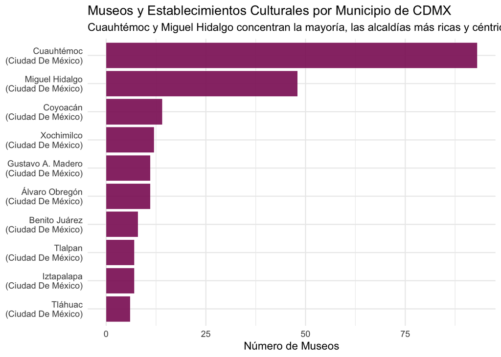

```r
museos_por_municipio <- museos_cdmx %>%
  count(municipio, entidad, sort = TRUE) %>%
  slice_head(n = 10) %>%
  mutate(etiqueta = paste0(municipio, "\n(", str_to_title(entidad), ")"))

g_mpm <- museos_por_municipio %>%
  mutate(etiqueta = fct_reorder(etiqueta, n)) %>%
  ggplot(aes(x = n, y = etiqueta)) +
  geom_col(fill = "maroon4", alpha = 0.9) +
  labs(title   = "Museos y Establecimientos Culturales por Municipio de CDMX",
       subtitle = "Cuauhtémoc y Miguel Hidalgo concentran la mayoría, las alcaldías más ricas y céntricas.",
       x = "Número de Museos", y = NULL) +
  theme_minimal()

g_mpm
```

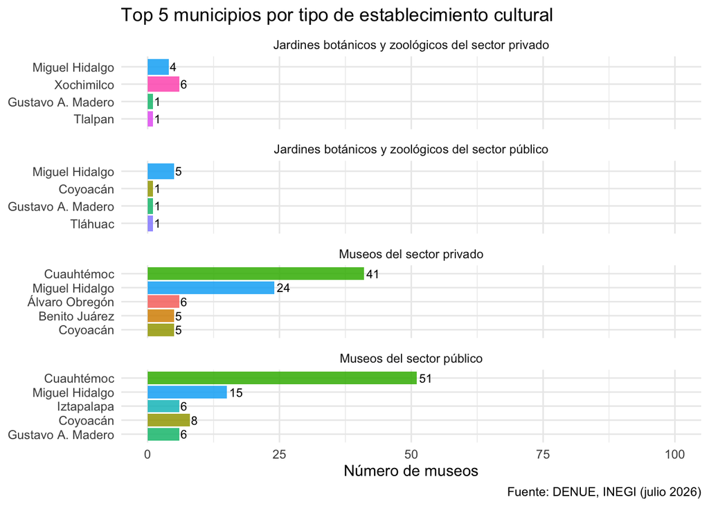

```r
museos_cdmx %>%
  filter(actividad %in% c("Museos del sector privado", "Museos del sector público", "Jardines botánicos y zoológicos del sector privado", "Jardines botánicos y zoológicos del sector público")
  ) %>%
  count(actividad, municipio) %>%
  group_by(actividad) %>%
  slice_max(n, n = 5) %>%
  ggplot(aes(x = n,
             y = reorder(municipio, n),
             fill = municipio)) +
  geom_col(show.legend = FALSE, alpha = 0.85) +
  geom_text(aes(label = n),
            hjust = -0.2, size = 3) +
  scale_x_continuous(limits = c(0, 100)) +
  facet_wrap(~ actividad, ncol = 1, scales = "free_y") +
  labs(
    title = "Top 5 municipios por tipo de establecimiento cultural",
    x = "Número de museos",
    y = NULL,
    caption = "Fuente: DENUE, INEGI (julio 2026)"
  ) +
  theme_minimal()
```

```

Interpretación de gráficas

Las gráficas muestran una concentración clara en Cuauhtémoc y Miguel Hidalgo, que son las dos alcaldías con mayor nivel socioeconómico e infraestructura urbana de la ciudad según el Índice de Bienestar Social de la CDMX. En cuanto a museos privados, Cuauhtémoc lidera con 41 y Miguel Hidalgo con 24. Esto tiene sentido porque los museos privados requieren rentabilidad, y se instalan donde hay mayor poder adquisitivo y turismo (Polanco, Roma, Centro Histórico). Por otro lado, los museos públicos se concentran también en Cuauhtémoc con 51, seguido de Miguel Hidalgo con 15. Sin embargo, aquí aparecen Iztapalapa (6) y Gustavo A. Madero (6), que son alcaldías populares. Lo que sugiere que el Estado sí intenta llevar establecimientos culturales a zonas más populares, aunque en mucho menor medida. Finalmente, los jardines y zoológicos están más dispersos y con números pequeños.

La oferta de museos en la CDMX no es equitativa. Los museos, privados y públicos, se concentran en alcaldías de alto nivel socioeconómico, mientras que alcaldías más populosas y con menor ingreso tienen una presencia mínima, casi exclusivamente de instituciones públicas. Esto sugiere que el acceso a la cultura depende en mucho en tu localidad y, por tanto, de tu nivel socioeconómico.